# Topic_Modeling_of_NLP_GitHub_repositories

This notebook uses the GitHub API to return popular NLP-related repositories. We then use spaCy and other NLP libraries to analyze the GitHub descriptions. In this way, we can attempt to get a sense of how NLP libraries are being used. That is, we are using NLP techniques to study NLP tools.

```python
API_KEY="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"  #@param {type:"string"}

NOTE="This API is valid till 3-4 days after my works"  #@param {type:"string"}
```

```python
!pip3 install pygithub
!pip3 install pyLDAvis
!pip3 install spacy-fastlang
```

```python
import warnings
warnings.filterwarnings("ignore", category=DeprecationWarning)
```

```python
import os
from github import Github
import spacy as sp
import pandas as pd
from spacy.language import Language
from spacy.tokens import Doc
import gensim
from gensim.models.ldamulticore import LdaMulticore
from gensim import corpora, models
import pyLDAvis.gensim_models
from wordcloud import WordCloud
from spacy_fastlang import LanguageDetector
import matplotlib.pyplot as plt
```

**Using GitHub API to search for NLP repos:**

Run a query with the following details:

1. Readme contains "NLP"
2. Language is Python
3. sort result by number of stars

```python
g=Github(API_KEY)
pages = g.search_repositories("NLP", sort='stars', order='desc', _in='readme', language='python')
```

# **Pre-process repo descriptions:**

Specifically, place all steps into a decorated custom pipeline

- keep only repos with descriptions <= 280 characters
- keep only repos where we are confident that the language is English
- remove "Awesome" lists
- remove stop words, punctuation, and then normalize text

I'll print the cleaned data too 👇

```python
@Language.component("clean_text")
def clean_text(doc):

    vocab=doc.vocab

    if len(doc.text) <= 280 \
        and doc._.language == 'en' \
        and doc._.language_score >=.8 \
        and not 'list' in doc.text.lower():

        text_list=[token.lemma_ for token in doc if not token.is_stop and not token.is_punct]

        return Doc(vocab, text_list)
```

```python
!python3 -m spacy download en_core_web_sm
```

```python
nlp = sp.load("en_core_web_sm")
nlp.add_pipe('language_detector')
nlp.add_pipe("clean_text", name="clean_text")
description_list=[repo.description for repo in pages[:99]]
docs=nlp.pipe(description_list)
docs=[doc.text for doc in docs if doc]
```

```python
docs
```

```
['deep Learning paper read roadmap eager learn amazing tech ',
 'tensorflow code pre train model BERT ',
 'repository track progress Natural Language Processing NLP include dataset current state art common NLP task ',
 'advanced Twitter scraping OSINT tool write Python use Twitter API allow scrape user follower follow tweet evade api limitation ',
 'simple framework state art Natural Language Processing NLP ',
 'open source NLP research library build PyTorch ',
 'kind text classification model deep learning ',
 'natural language modeling framework base PyTorch ',
 'Neural Net Training Interface TensorFlow focus speed + flexibility ',
 'open source python library automate feature engineering ',
 'open source library deep learning end end dialog system chatbot ',
 'MMdnn set tool help user inter operate different deep learning framework e.g. model conversion visualization convert model Caffe Keras MXNet Tensorflow CNTK PyTorch Onnx CoreML ',
 'official implementation pre training model ernie family cover topic Language Understanding Generation Multimodal Understanding Generation ',
 'code paper explore limit Transfer Learning Unified text Text transformer ',
 'high level library help training evaluate neural network PyTorch flexibly transparently ',
 'dataset format AI easily build manage dataset machine deep learning stream datum real time version control https://activeloop.ai ',
 'Snips Python library extract mean text ',
 'large scale self supervise Pre training Tasks language modality ',
 'fix mojibake glitch Unicode text fact ',
 'data loader abstraction text NLP ',
 'optimizer train fast Adam good SGD ',
 'library Multilingual Unsupervised supervised word embedding ',
 'model interpretability understanding PyTorch ',
 'Language Interpretability Tool interactively analyze NLP model model understanding extensible framework agnostic interface ',
 'mag Haystack open source NLP framework leverage transformer model enable developer implement production ready neural search question answer semantic document search summarization wide range application ',
 'Python package RPA ',
 'NLP easy ',
 'final Weibo Crawler Scrap Weibo comment weibo content follower Terminator ',
 'easy use NLP library Awesome pre train model zoo   support wide range NLP task research industrial application ',
 'implementation BERT load official pre train model feature extraction prediction ',
 'Kashgari production level NLP Transfer learning framework build tf.kera text labeling text classification include Word2Vec BERT GPT2 Language Embedding ',
 'sent2vec encoder training code paper Skip Thought vector ',
 'pretraine language model related optimization technique develop Huawei Noah Ark Lab ',
 'cnn sentence classification ',
 '🚀 simple way train use PyTorch model multi GPU TPU mixed precision ',
 'electra pre train Text encoder Discriminators generator ']
```

# Now we're ready to do the topic modeling

- building a bag of words (BOW). This stores the frequency of each word in our dataset
- applying the LDA modeling

```python
dictionary = corpora.Dictionary(d.split() for d in docs)
bow = [dictionary.doc2bow(d.split()) for d in docs]
lda = gensim.models.ldamodel.LdaModel
num_topics=3
ldamodel = lda(bow,num_topics=num_topics,id2word=dictionary,passes=50,minimum_probability=0)
```

```python
ldamodel.print_topics(num_topics=num_topics)
```

```
[(0,
  '0.046*"model" + 0.018*"train" + 0.018*"learning" + 0.018*"text" + 0.018*"pre" + 0.018*"PyTorch" + 0.018*"framework" + 0.014*"deep" + 0.013*"Language" + 0.013*"BERT"'),
 (1,
  '0.045*"NLP" + 0.035*"library" + 0.021*"source" + 0.021*"open" + 0.016*"text" + 0.011*"search" + 0.011*"wide" + 0.011*"range" + 0.011*"application" + 0.011*"task"'),
 (2,
  '0.016*"Twitter" + 0.016*"follower" + 0.016*"Weibo" + 0.009*"Python" + 0.009*"use" + 0.009*"Learning" + 0.009*"training" + 0.009*"language" + 0.009*"user" + 0.009*"tool"')]
```

# **Visualizing topic modeling**

- word cloud
- interactive chart with pyLDAvis

**Let's make a word cloud for each topic in our model**

- The larger the word, the more frequently it occurs in a given topic

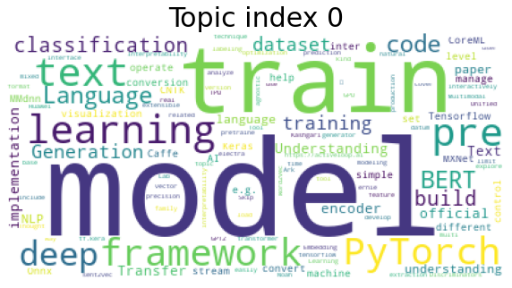

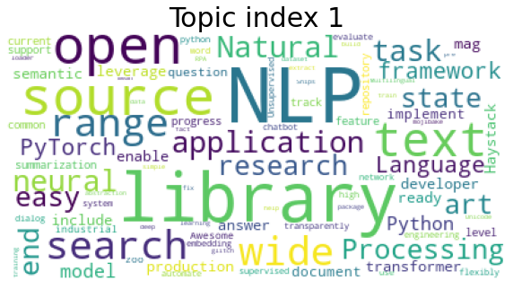

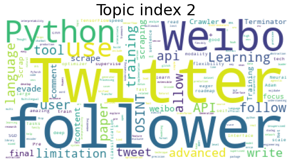

```python
for t in range(ldamodel.num_topics):
    plt.figure(figsize=(10,10))
    plt.imshow(WordCloud(background_color='white').fit_words(dict(ldamodel.show_topic(t, 200))))
    plt.axis("off")
    plt.title("Topic index " + str(t), fontdict={'size': 30})
    plt.show()
```

# **Using pyLDAvis to examine topic modeling results**

- This is the classic way of interactively visualizing topic modeling
- Click the topics on the left to filter the bar chart
- It is good that our three topics appear to be independent of one another (there is no overlap - more can be done to explore this)

```python
pyLDAvis.enable_notebook()
pyLDAvis.gensim_models.prepare(ldamodel, bow, dictionary)
```

[interactive chart not shown]